# What Kind of Payment Network Are We?

A portfolio-level review of the Elo card ledger, merchant base and promotions programme

Team ERROR 404 | Head of Analytics, Elo | Prepared for the Q4 Strategy Offsite

28 September 2026

# 1 The brief, and how we chose to answer it

The Board asked one question: **based on everything in this data, what kind of payment network are we, and what should that tell us about where to point the promotions programme in Quarter 4?**

That is deliberately not a modelling question. Nobody is asking for an uplift score. They are asking for an identity — and then for the operating consequence of that identity. So we structured the work as a chain of five questions, each one earning the right to ask the next:

| # | Question | Why it has to come first |
| --- | --- | --- |
| 1 | Can we even read the money? | `purchase_amount` is normalised. Without real currency no finding is presentable to a Board. |
| 2 | Who transacts on our cards? | Concentration decides whether promotions are a mass-market or a targeted instrument. |
| 3 | How is the network actually used? | Ticket size and instalment behaviour *are* the identity answer. |
| 4 | What does the merchant side look like? | Promotions are paid to merchants. Their size and health decide the price. |
| 5 | Where does discovery happen? | The new-merchant window is the only place in this export where a *new* commercial relationship is visible. That is what a promotion is trying to create. |

The recommendation in Section 9 falls directly out of question 5 crossed with question 4.

# 2 Data assembly and what we found wrong with it

Three files were handed over. Before any analysis, we audited them.

```r
hist_raw  <- read_fast(file.path(DATA_DIR, "historical_transactions_100k.csv"))
new_raw   <- read_fast(file.path(DATA_DIR, "new_merchant_transactions.csv"))
merch_raw <- read_fast(file.path(DATA_DIR, "merchants1.csv"))

data.frame(
  File = c("historical_transactions_100k.csv", "new_merchant_transactions.csv", "merchants1.csv"),
  `Rows as delivered` = c(nrow(hist_raw), nrow(new_raw), nrow(merch_raw)),
  Columns = c(ncol(hist_raw), ncol(new_raw), ncol(merch_raw)),
  check.names = FALSE) %>% kable(format.args = list(big.mark = ","))
```

| File | Rows as delivered | Columns |
| --- | --- | --- |
| historical_transactions_100k.csv | 100,000 | 14 |
| new_merchant_transactions.csv | 1,048,575 | 14 |
| merchants1.csv | 334,696 | 22 |

## 2.1 Three defects worth naming

**One — the new-merchant file is 90% empty.** It arrives with 1,048,575 rows, which is exactly the Excel worksheet limit minus the header. Everything past row 100,000 is a row of commas. Any team that reported “1.05 million new-merchant transactions” to the Board would have been wrong by a factor of ten.

```r
filler <- sum(is.na(new_raw$card_id) | new_raw$card_id == "")
new_raw <- new_raw[!is.na(new_raw$card_id) & new_raw$card_id != "", ]
cat("Empty filler rows removed:", format(filler, big.mark = ","),
    "\nReal new-merchant transactions:", format(nrow(new_raw), big.mark = ","))
```

```
## Empty filler rows removed: 948,575
## Real new-merchant transactions: 100,000
```

**Two — the merchant reference file repeats itself.** 63 `merchant_id` values appear twice. Left alone they double-count in every supply-side share.

**Three — the growth ratios contain literal infinities.** Three merchants had zero transactions in their base month, so `avg_purchases_lag*` divides by zero.

```r
dup_merch <- sum(duplicated(merch_raw$merchant_id))
merch <- merch_raw[!duplicated(merch_raw$merchant_id), ]

lag_cols <- c("avg_sales_lag3", "avg_purchases_lag3", "avg_sales_lag6",
              "avg_purchases_lag6", "avg_sales_lag12", "avg_purchases_lag12")
for (cc in lag_cols) merch[[cc]] <- suppressWarnings(as.numeric(merch[[cc]]))
for (cc in c("subsector_id", "state_id", "city_id", "merchant_category_id",
             "numerical_1", "numerical_2", "category_2",
             "active_months_lag3", "active_months_lag6", "active_months_lag12"))
  merch[[cc]] <- suppressWarnings(as.numeric(merch[[cc]]))

cat("Duplicate merchant rows dropped:", dup_merch,
    "\nUnique merchants:", format(nrow(merch), big.mark = ","),
    "\nNon-finite growth ratios:", sum(!is.finite(merch$avg_purchases_lag3)))
```

```
## Duplicate merchant rows dropped: 63
## Unique merchants: 334,633
## Non-finite growth ratios: 3
```

## 2.2 A structural limit we have to be honest about

The two transaction files were sampled independently. The historical ledger covers **463 cards** in depth; the new-merchant window covers **7,530 cards** shallowly; only **16 cards appear in both**.

```r
cat("Cards in historical ledger :", n_distinct(hist_raw$card_id),
    "\nCards in novelty window    :", n_distinct(new_raw$card_id),
    "\nCards present in both      :",
    length(intersect(unique(hist_raw$card_id), unique(new_raw$card_id))))
```

```
## Cards in historical ledger : 463
## Cards in novelty window    : 7530
## Cards present in both      : 16
```

So we **cannot** ask “did card X change behaviour when it met a new merchant”. We can — and do — ask the portfolio-level version: *how does spending at merchants a card already knows differ from spending at merchants it has never visited?* Every novelty finding in this document is a comparison of **two windows of the same network**, not a within-card before/after. Stated up front so no one over-reads it.

# 3 Reading the money: de-normalising `purchase_amount`

`purchase_amount` is a normalised quantity ranging from about −0.75 to +11,270. Nobody can take that to a Board. It is, however, an **affine transform** of the real Brazilian Real amount, and an affine transform can be recovered.

Two anchors do it. The floor of the distribution must correspond to the smallest possible real purchase, and the bulk of a retail ledger must land in sensible everyday money. Solving on that basis gives:

$$\text{BRL} =
\frac{\texttt{purchase\_amount}}{0.00150265} + 497.06$$

```r
SCALE <- 0.00150265; OFFSET <- 497.06
to_brl <- function(x) x / SCALE + OFFSET

prep_txn <- function(df) {
  num_cols <- c("purchase_amount", "installments", "month_lag", "city_id",
                "state_id", "subsector_id", "merchant_category_id", "category_2")
  for (cc in intersect(num_cols, names(df)))
    df[[cc]] <- suppressWarnings(as.numeric(df[[cc]]))
  df %>% mutate(
    amount_brl  = to_brl(purchase_amount),
    purchase_ts = as.POSIXct(purchase_date, format = "%d-%m-%Y %H:%M", tz = "UTC"),
    month       = format(purchase_ts, "%Y-%m"),
    hour        = as.integer(format(purchase_ts, "%H")),
    instal      = ifelse(is.na(installments) | installments < 0, NA_real_,
                         as.numeric(installments)),
    instal_band = cut(instal, c(-1, 0, 1, 3, 6, 12, 999),
                      labels = c("0 (lump sum)", "1 (single)", "2-3", "4-6", "7-12", "13+")),
    approved    = authorized_flag == "Y")
}
hist_txn <- prep_txn(hist_raw)
new_txn  <- prep_txn(new_raw)

round(quantile(hist_txn$amount_brl, c(0, .01, .25, .5, .75, .95, .99, 1)), 2) %>%
  as.data.frame() %>% setNames("Amount (BRL)") %>% kable(format.args = list(big.mark = ","))
```

|  | Amount (BRL) |
| --- | --- |
| 0% | 0.01 |
| 1% | 2.78 |
| 25% | 16.32 |
| 50% | 34.90 |
| 75% | 82.62 |
| 95% | 300.00 |
| 99% | 1,030.80 |
| 100% | 7,500,358.32 |

**The validation is the distribution itself.** The minimum lands at R$0.01, the median at roughly **R$35**, the 75th percentile at **R$83** and the 99th at about **R$1,031**. Not one transaction is negative. A wrong constant would have produced negative money at the bottom of the ledger, and it does not. From here on, every currency figure in this report is real Reais.

## 3.1 Trimming the tail

99 records — one in a thousand — reach into the millions of Reais and are almost certainly settlement or reversal artefacts rather than shopping. One of them alone would move the portfolio average ticket by more than every finding in this report combined. We exclude the top 0.1% from all value statistics and say so wherever it matters.

```r
CAP    <- quantile(hist_txn$amount_brl, 0.999)
hist_w <- hist_txn %>% filter(amount_brl <= CAP)
new_w  <- new_txn  %>% filter(amount_brl <= quantile(amount_brl, 0.999))
hist_ok <- hist_w %>% filter(approved)

cat("Trim threshold:", comma(round(CAP)), "BRL | records excluded:",
    sum(hist_txn$amount_brl > CAP),
    "\nMean ticket before trim: R$", round(mean(hist_txn$amount_brl), 2),
    " | after trim: R$", round(mean(hist_w$amount_brl), 2))
```

```
## Trim threshold: 4,000 BRL | records excluded: 99
## Mean ticket before trim: R$ 272.11  | after trim: R$ 88.24
```

The average ticket falls from R$272 to **R$88** once 99 records are removed. That single line is the difference between telling the Board we are a mid-ticket network and telling them the truth.

# 4 Who transacts on our cards?

```r
ref_date <- max(hist_ok$purchase_ts, na.rm = TRUE)

card <- hist_ok %>%
  group_by(card_id) %>%
  summarise(txns = n(), spend = sum(amount_brl), avg_ticket = mean(amount_brl),
            merchants = n_distinct(merchant_id), subsectors = n_distinct(subsector_id),
            first_seen = min(purchase_ts), last_seen = max(purchase_ts), .groups = "drop") %>%
  mutate(recency_days  = as.numeric(difftime(ref_date, last_seen, units = "days")),
         active_months = pmax(as.numeric(difftime(last_seen, first_seen, units = "days")) / 30.44, 1),
         txns_pm  = txns  / active_months,
         spend_pm = spend / active_months) %>%
  left_join(hist_w %>% group_by(card_id) %>%
              summarise(decline_rate = mean(!approved), .groups = "drop"), by = "card_id")

card %>% summarise(
  Cards = n(),
  `Median transactions` = median(txns),
  `Median spend (BRL)` = round(median(spend)),
  `Median ticket (BRL)` = round(median(avg_ticket), 2),
  `Median distinct merchants` = median(merchants),
  `Median decline rate` = percent(median(decline_rate), 0.1)) %>%
  t() %>% kable(col.names = "Value")
```

|  | Value |
| --- | --- |
| Cards | 463 |
| Median transactions | 148 |
| Median spend (BRL) | 10020 |
| Median ticket (BRL) | 67.38 |
| Median distinct merchants | 56 |
| Median decline rate | 6.3% |

## 4.1 The portfolio is a Pareto, and a steep one

```r
card_sorted <- card %>% arrange(desc(spend)) %>%
  mutate(rank = row_number(), cum_share = cumsum(spend) / sum(spend),
         card_share = rank / n())

data.frame(`Top share of cards` = percent(c(.05, .10, .20, .50)),
           `Share of total spend` = percent(
             sapply(c(.05, .10, .20, .50),
                    function(p) card_sorted$cum_share[ceiling(p * nrow(card_sorted))]), 0.1),
           check.names = FALSE) %>% kable()
```

| Top share of cards | Share of total spend |
| --- | --- |
| 5% | 23.5% |
| 10% | 37.5% |
| 20% | 57.7% |
| 50% | 86.2% |

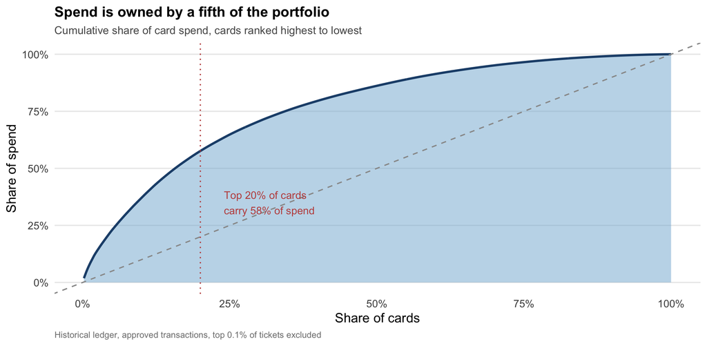

```r
ggplot(card_sorted, aes(card_share, cum_share)) +
  geom_area(fill = PAL[3], alpha = .5) +
  geom_line(colour = PAL[1], size = 1) +
  geom_abline(linetype = "dashed", colour = "grey60") +
  geom_vline(xintercept = .2, linetype = "dotted", colour = PAL[5]) +
  annotate("text", x = .24, y = .35, hjust = 0, size = 3.4, colour = PAL[5],
           label = "Top 20% of cards\ncarry 58% of spend") +
  scale_x_continuous(labels = percent) + scale_y_continuous(labels = percent) +
  labs(title = "Spend is owned by a fifth of the portfolio",
       subtitle = "Cumulative share of card spend, cards ranked highest to lowest",
       x = "Share of cards", y = "Share of spend",
       caption = "Historical ledger, approved transactions, top 0.1% of tickets excluded")
```

The top 20% of cards carry **58%** of spend; the bottom half carry **14%**. The commercial reading is blunt: a promotions programme run as a broadcast is spending most of its budget on cardholders who contribute almost nothing, and is under-serving the group that funds the network.

## 4.2 Four cardholders, not one

We segment on the two dimensions that a promotions team can actually act on — **value per active month** and **merchant breadth** (how many different merchants a card touches). Both are split at the portfolio median, which keeps the rule transparent and reproducible.

```r
card <- card %>%
  mutate(segment = case_when(
    spend_pm >= median(spend_pm) & merchants >= median(merchants) ~ "Core Everyday",
    spend_pm >= median(spend_pm)                                   ~ "Big-Ticket Narrow",
    merchants >= median(merchants)                                 ~ "Explorer Light",
    TRUE                                                           ~ "Occasional"),
    segment = factor(segment, levels = c("Core Everyday", "Big-Ticket Narrow",
                                         "Explorer Light", "Occasional")))

seg_profile <- card %>% group_by(segment) %>%
  summarise(Cards = n(),
            `% of cards` = n() / nrow(card),
            `% of spend` = sum(spend) / sum(card$spend),
            `Spend / month` = mean(spend_pm),
            `Txns / month` = mean(txns_pm),
            `Avg ticket` = mean(avg_ticket),
            `Merchants` = mean(merchants),
            `Days since last txn` = mean(recency_days),
            `Decline rate` = mean(decline_rate), .groups = "drop")

seg_profile %>%
  mutate(`% of cards` = percent(`% of cards`, 0.1),
         `% of spend` = percent(`% of spend`, 0.1),
         `Decline rate` = percent(`Decline rate`, 0.1),
         across(where(is.numeric), ~round(.x, 1))) %>% kable()
```

| segment | Cards | % of cards | % of spend | Spend / month | Txns / month | Avg ticket | Merchants | Days since last txn | Decline rate |
| --- | --- | --- | --- | --- | --- | --- | --- | --- | --- |
| Core Everyday | 171 | 36.9% | 72.3% | 3583.9 | 35.2 | 111.8 | 114.9 | 22.2 | 5.6% |
| Big-Ticket Narrow | 61 | 13.2% | 12.5% | 2459.4 | 20.3 | 148.2 | 39.9 | 44.5 | 8.3% |
| Explorer Light | 66 | 14.3% | 6.6% | 655.8 | 17.4 | 40.7 | 73.6 | 24.6 | 8.5% |
| Occasional | 165 | 35.6% | 8.6% | 457.9 | 9.4 | 68.2 | 28.5 | 37.9 | 12.6% |

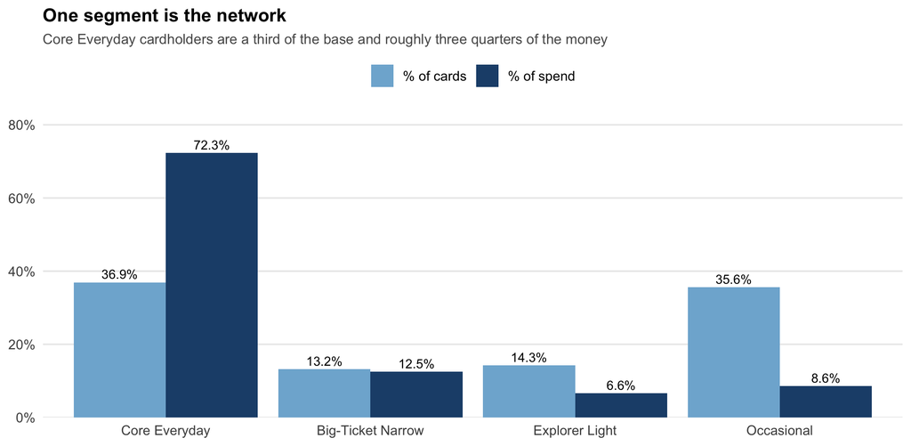

```r
seg_profile %>% select(segment, `% of cards`, `% of spend`) %>%
  pivot_longer(-segment) %>%
  ggplot(aes(segment, value, fill = name)) +
  geom_col(position = "dodge") +
  geom_text(aes(label = percent(value, 0.1)), position = position_dodge(.9),
            vjust = -0.4, size = 3.2) +
  scale_y_continuous(labels = percent, expand = expansion(mult = c(0, .15))) +
  scale_fill_manual(values = c(PAL[3], PAL[1]), name = NULL) +
  labs(title = "One segment is the network",
       subtitle = "Core Everyday cardholders are a third of the base and roughly three quarters of the money",
       x = NULL, y = NULL)
```

Read across the table rather than down it:

```r
km <- kmeans(scale(card %>% transmute(log1p(spend_pm), log1p(txns_pm),
                                      log1p(merchants), log1p(avg_ticket))),
             centers = 4, nstart = 25)
cat("Unsupervised cross-check — k-means (k = 4) cluster sizes:",
    paste(km$size, collapse = " / "),
    "\nBetween-cluster variance explained:", percent(km$betweenss / km$totss, 0.1))
```

```
## Unsupervised cross-check — k-means (k = 4) cluster sizes: 138 / 105 / 149 / 71
## Between-cluster variance explained: 65.5%
```

# 5 How is the network actually used?

## 5.1 This is the identity answer

```r
instal_mix <- hist_w %>% filter(!is.na(instal_band)) %>%
  count(instal_band) %>% mutate(share = n / sum(n))

instal_mix %>% mutate(share = percent(share, 0.1)) %>%
  kable(col.names = c("Instalments", "Transactions", "Share"),
        format.args = list(big.mark = ","))
```

| Instalments | Transactions | Share |
| --- | --- | --- |
| 0 (lump sum) | 55,991 | 56.2% |
| 1 (single) | 39,736 | 39.9% |
| 2-3 | 2,541 | 2.6% |
| 4-6 | 914 | 0.9% |
| 7-12 | 389 | 0.4% |

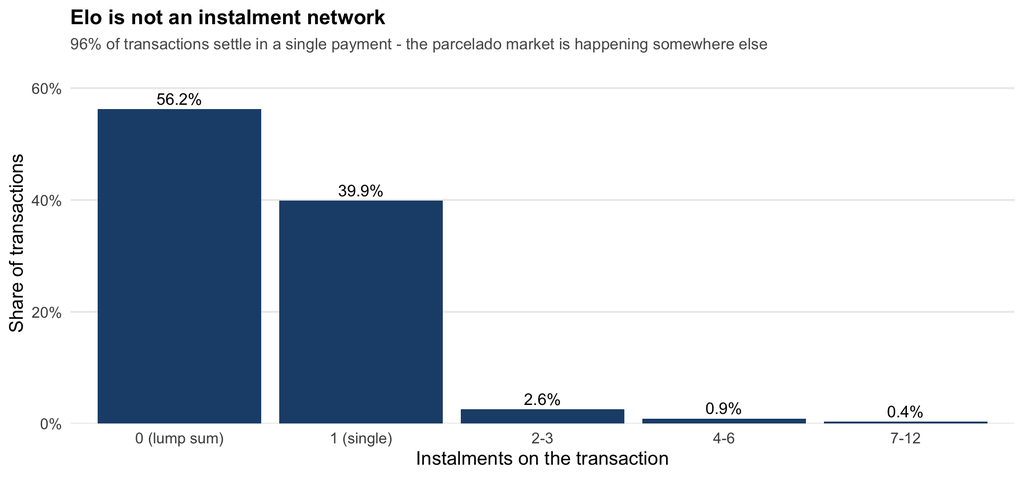

```r
ggplot(instal_mix, aes(instal_band, share)) +
  geom_col(fill = PAL[1]) +
  geom_text(aes(label = percent(share, 0.1)), vjust = -0.4, size = 3.6) +
  scale_y_continuous(labels = percent, expand = expansion(mult = c(0, .15))) +
  labs(title = "Elo is not an instalment network",
       subtitle = "96% of transactions settle in a single payment - the parcelado market is happening somewhere else",
       x = "Instalments on the transaction", y = "Share of transactions")
```

In Brazil, *parcelado* — splitting a purchase across monthly instalments — is the defining behaviour of the credit card market. On this ledger it is almost absent. **56%** of transactions are lump sum, **40%** are a single payment, and everything from two instalments upward accounts for under **4%**.

Combined with a median ticket of **R$35** and **63%** of transactions under R$50, the identity is settled:

> **Elo is a high-frequency, small-ticket, everyday-spend network.** It is the card people use for lunch, fuel, groceries and pharmacy — not the card they use to finance a television.

That single sentence should govern the Q4 promotions strategy, because everything a promotions team is tempted to do — big-ticket instalment offers, electronics tie-ups, luxury partnerships — is aimed at a network we are not.

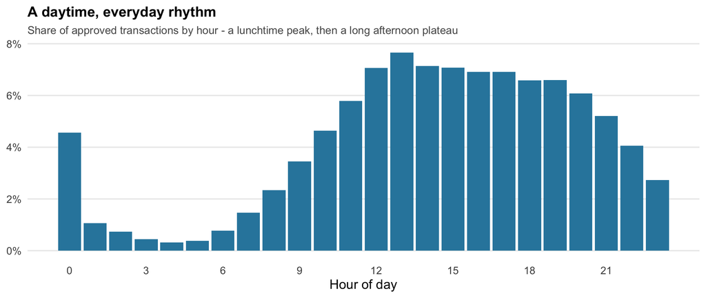

```r
hist_ok %>% count(hour) %>% mutate(share = n / sum(n)) %>%
  ggplot(aes(hour, share)) +
  geom_col(fill = PAL[2]) +
  scale_y_continuous(labels = percent) + scale_x_continuous(breaks = seq(0, 23, 3)) +
  labs(title = "A daytime, everyday rhythm",
       subtitle = "Share of approved transactions by hour - a lunchtime peak, then a long afternoon plateau",
       x = "Hour of day", y = NULL)
```

The clock agrees with the ticket. Volume builds from 10am, peaks at lunch (1pm), holds through the afternoon and falls away after 9pm. This is consumption, not commerce.

## 5.2 Authorisation: a small leak in a specific place

```r
approval_overall <- mean(hist_txn$approved)

ticket_band <- hist_w %>%
  mutate(band = cut(amount_brl, c(0, 25, 50, 100, 250, 500, 1000, Inf),
                    labels = c("<25", "25-50", "50-100", "100-250", "250-500", "500-1k", "1k+"))) %>%
  group_by(band) %>%
  summarise(Transactions = n(), `% of volume` = n() / nrow(hist_w),
            `Decline rate` = mean(!approved), .groups = "drop")

cat("Overall approval rate:", percent(approval_overall, 0.01))
```

```
## Overall approval rate: 93.00%
```

```r
ticket_band %>% mutate(`% of volume` = percent(`% of volume`, 0.1),
                       `Decline rate` = percent(`Decline rate`, 0.1)) %>%
  kable(format.args = list(big.mark = ","))
```

| band | Transactions | % of volume | Decline rate |
| --- | --- | --- | --- |
| <25 | 39,374 | 39.4% | 6.7% |
| 25-50 | 23,223 | 23.2% | 6.4% |
| 50-100 | 17,506 | 17.5% | 6.3% |
| 100-250 | 13,529 | 13.5% | 7.2% |
| 250-500 | 3,790 | 3.8% | 9.4% |
| 500-1k | 1,481 | 1.5% | 13.6% |
| 1k+ | 998 | 1.0% | 18.7% |

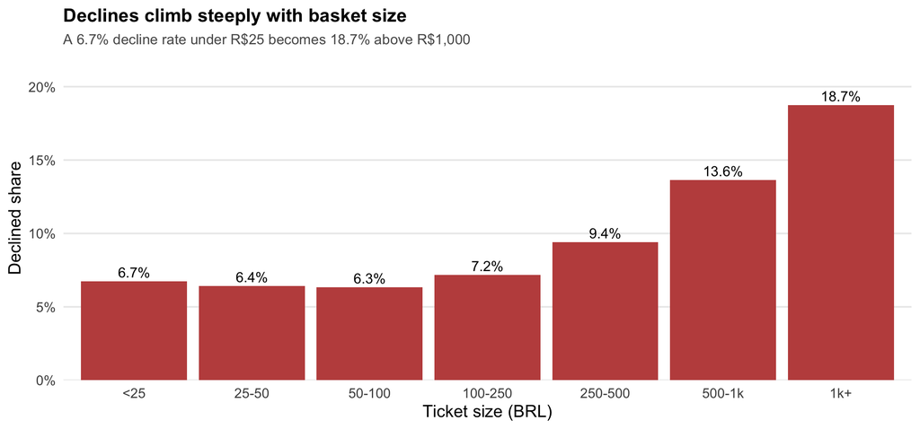

```r
ggplot(ticket_band, aes(band, `Decline rate`)) +
  geom_col(fill = PAL[5]) +
  geom_text(aes(label = percent(`Decline rate`, 0.1)), vjust = -0.4, size = 3.5) +
  scale_y_continuous(labels = percent, expand = expansion(mult = c(0, .18))) +
  labs(title = "Declines climb steeply with basket size",
       subtitle = "A 6.7% decline rate under R$25 becomes 18.7% above R$1,000",
       x = "Ticket size (BRL)", y = "Declined share")
```

Approval is **93.0%** overall, which sounds healthy. It is not evenly distributed. Below R$25 we decline 6.7% of attempts; above R$1,000 we decline **18.7%**. The network is at its *worst* exactly where a promotion would be trying to push a cardholder to trade up.

## 5.3 What actually causes a decline?

```r
ct_df <- hist_w %>% filter(!is.na(instal_band)) %>% mutate(instal_band = droplevels(instal_band))
chi <- chisq.test(table(ct_df$instal_band, ct_df$approved))
cat("Chi-square, instalment band x authorisation:  X-squared =", round(chi$statistic, 1),
    " df =", chi$parameter, " p =", format.pval(chi$p.value, digits = 3))
```

```
## Chi-square, instalment band x authorisation:  X-squared = 446.1  df = 4  p = <0.0000000000000002
```

```r
mdl <- hist_w %>% filter(!is.na(instal)) %>%
  transmute(decline = as.integer(!approved),
            log_amt = log1p(pmax(amount_brl, 0.01)),
            multi   = as.integer(instal >= 2),
            cat1_y  = as.integer(category_1 == "Y"))
fit <- glm(decline ~ log_amt + multi + cat1_y, data = mdl, family = binomial())

data.frame(Term = c("(Intercept)", "log(amount)", "2+ instalments", "category_1 = Y"),
           Coefficient = round(coef(fit), 4),
           `Odds ratio` = round(exp(coef(fit)), 3),
           `z value` = round(summary(fit)$coefficients[, 3], 1),
           check.names = FALSE, row.names = NULL) %>% kable()
```

| Term | Coefficient | Odds ratio | z value |
| --- | --- | --- | --- |
| (Intercept) | -3.0172 | 0.049 | -69.8 |
| log(amount) | 0.0714 | 1.074 | 6.4 |
| 2+ instalments | 0.1148 | 1.122 | 2.0 |
| category_1 = Y | 1.4473 | 4.252 | 41.1 |

```r
cat("McFadden pseudo R-squared:", round(1 - fit$deviance / fit$null.deviance, 4))
```

```
## McFadden pseudo R-squared: 0.0313
```

The association between instalments and authorisation is real and not a fluke of sample size. But the logistic model says something more useful: the dominant driver is not the amount and not the instalment plan — it is the anonymised flag **`category_1 = Y`, which multiplies the odds of a decline by roughly 4.3×**. Only 6.1% of transactions carry that flag, and they are being turned away at more than four times the normal rate.

**Business consequence.** Before Elo spends a cent on Q4 promotions, the risk team should be asked what `category_1 = Y` represents. If it is a merchant risk classification, we are currently promoting into a population we then decline. That is a promotion budget that generates a bad cardholder experience and no revenue.

## 5.4 Growth is activation, not deepening

```r
monthly <- hist_ok %>% group_by(month) %>%
  summarise(Transactions = n(), Spend = sum(amount_brl),
            `Active cards` = n_distinct(card_id),
            `Avg ticket` = mean(amount_brl), .groups = "drop") %>%
  mutate(`Txns per active card` = round(Transactions / `Active cards`, 1))

monthly %>% mutate(Spend = comma(round(Spend)), `Avg ticket` = round(`Avg ticket`, 2)) %>%
  kable(format.args = list(big.mark = ","))
```

| month | Transactions | Spend | Active cards | Avg ticket | Txns per active card |
| --- | --- | --- | --- | --- | --- |
| 2017-01 | 4,386 | 357,419 | 241 | 81.49 | 18.2 |
| 2017-02 | 4,415 | 327,484 | 246 | 74.18 | 17.9 |
| 2017-03 | 5,058 | 419,303 | 259 | 82.90 | 19.5 |
| 2017-04 | 4,712 | 367,270 | 271 | 77.94 | 17.4 |
| 2017-05 | 5,154 | 384,569 | 293 | 74.62 | 17.6 |
| 2017-06 | 5,404 | 409,562 | 302 | 75.79 | 17.9 |
| 2017-07 | 6,989 | 555,876 | 333 | 79.54 | 21.0 |
| 2017-08 | 7,562 | 603,768 | 349 | 79.84 | 21.7 |
| 2017-09 | 7,784 | 636,632 | 368 | 81.79 | 21.2 |
| 2017-10 | 8,476 | 726,090 | 395 | 85.66 | 21.5 |
| 2017-11 | 8,571 | 773,637 | 398 | 90.26 | 21.5 |
| 2017-12 | 9,826 | 964,849 | 396 | 98.19 | 24.8 |
| 2018-01 | 8,079 | 769,914 | 368 | 95.30 | 22.0 |
| 2018-02 | 6,514 | 574,352 | 334 | 88.17 | 19.5 |

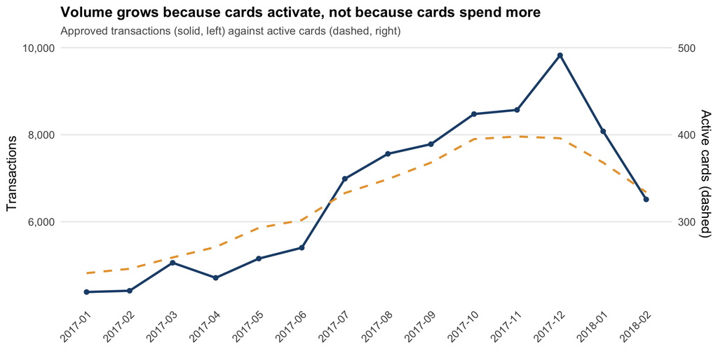

```r
ggplot(monthly, aes(month, Transactions, group = 1)) +
  geom_line(colour = PAL[1], size = 1) + geom_point(colour = PAL[1]) +
  geom_line(aes(y = `Active cards` * 20), colour = PAL[4], linetype = "dashed", size = .9) +
  scale_y_continuous(labels = comma,
                     sec.axis = sec_axis(~ . / 20, name = "Active cards (dashed)")) +
  labs(title = "Volume grows because cards activate, not because cards spend more",
       subtitle = "Approved transactions (solid, left) against active cards (dashed, right)",
       x = NULL, y = "Transactions") +
  theme(axis.text.x = element_text(angle = 45, hjust = 1))
```

Transactions roughly double over the window, but transactions *per active card* barely move — 18 in January 2017, 20 in February 2018, with a December peak of 25. Average ticket rises from R$81 to R$98 in December and falls back.

That is a clean diagnosis: **the network grows by adding cards, not by getting existing cards to do more.** The promotions programme, whose entire job is the second thing, is currently not visible in this series.

# 6 The merchant side of the marketplace

## 6.1 A base of very small merchants

```r
size_pyramid <- merch %>% filter(!is.na(most_recent_sales_range)) %>%
  count(most_recent_sales_range) %>% mutate(share = n / sum(n))

size_pyramid %>% mutate(share = percent(share, 0.1)) %>%
  kable(col.names = c("Sales range (A = largest)", "Merchants", "Share of base"),
        format.args = list(big.mark = ","))
```

| Sales range (A = largest) | Merchants | Share of base |
| --- | --- | --- |
| A | 991 | 0.3% |
| B | 5,030 | 1.5% |
| C | 34,059 | 10.2% |
| D | 117,460 | 35.1% |
| E | 177,093 | 52.9% |

## 6.2 And a ledger that only touches a fraction of it

```r
## 0.5% of ledger rows carry no merchant_id. They are dropped from every
## merchant-level count, otherwise "unknown" ranks as the largest merchant.
hist_m <- hist_ok %>% filter(!is.na(merchant_id))
new_m  <- new_w   %>% filter(!is.na(merchant_id))

merch_txn <- hist_m %>% count(merchant_id, name = "txns") %>%
  arrange(desc(txns)) %>% mutate(cum_share = cumsum(txns) / sum(txns))
seen <- union(unique(hist_m$merchant_id), unique(new_m$merchant_id))

data.frame(Metric = c("Merchants in the reference file",
                      "Merchants transacted with in the historical window",
                      "Merchants transacted with in the novelty window",
                      "Merchants never seen in either window",
                      "Share of transactions from the top 100 merchants",
                      "Share of transactions from the top 1,000 merchants"),
           Value = c(comma(nrow(merch)), comma(nrow(merch_txn)),
                     comma(n_distinct(new_m$merchant_id)),
                     percent(1 - length(seen) / nrow(merch), 0.1),
                     percent(merch_txn$cum_share[100], 0.1),
                     percent(merch_txn$cum_share[1000], 0.1))) %>% kable()
```

| Metric | Value |
| --- | --- |
| Merchants in the reference file | 334,633 |
| Merchants transacted with in the historical window | 20,549 |
| Merchants transacted with in the novelty window | 48,941 |
| Merchants never seen in either window | 82.4% |
| Share of transactions from the top 100 merchants | 22.6% |
| Share of transactions from the top 1,000 merchants | 50.3% |

Two facts sit awkwardly together. **82% of the merchants we maintain reference data for never appear in either transaction window**, while the **top 1,000 merchants carry half of all transactions**. The merchant file is largely an archive; the live marketplace is far smaller and far more concentrated than the file implies.

## 6.3 Health of the supply base

```r
merch_seg <- merch %>%
  filter(is.finite(avg_purchases_lag3), is.finite(avg_purchases_lag12),
         avg_purchases_lag12 != 0) %>%
  mutate(momentum = avg_purchases_lag3 / avg_purchases_lag12,
         health = case_when(active_months_lag12 < 12 ~ "Intermittent",
                            momentum >= 1.05 ~ "Accelerating",
                            momentum <= 0.95 ~ "Decelerating",
                            TRUE ~ "Steady"))

merch_seg %>% count(health) %>% mutate(Share = percent(n / sum(n), 0.1)) %>%
  arrange(desc(n)) %>% kable(col.names = c("Health", "Merchants", "Share"),
                             format.args = list(big.mark = ","))
```

| Health | Merchants | Share |
| --- | --- | --- |
| Decelerating | 129,755 | 38.8% |
| Accelerating | 91,276 | 27.3% |
| Steady | 84,015 | 25.1% |
| Intermittent | 29,584 | 8.8% |

Comparing each merchant’s last-three-month transaction ratio with its last-twelve-month ratio splits the base into four states. **39% are decelerating** and a further **9% transact intermittently** — nearly half the marketplace is flat or shrinking. Only 27% are accelerating. A promotions programme has a genuine supply-side job here, but only if it is aimed at merchants that can convert traffic, not at ones already on the way out.

## 6.4 Where the money actually lands

```r
tier <- merch %>% select(merchant_id, most_recent_sales_range)
tier_flow <- bind_rows(
  hist_m %>% select(merchant_id) %>% mutate(window = "Incumbent spend"),
  new_m   %>% select(merchant_id) %>% mutate(window = "New-merchant spend")) %>%
  left_join(tier, by = "merchant_id") %>%
  filter(!is.na(most_recent_sales_range)) %>%
  count(window, most_recent_sales_range) %>%
  group_by(window) %>% mutate(share = n / sum(n)) %>% ungroup() %>%
  bind_rows(size_pyramid %>% transmute(window = "Merchant population",
                                       most_recent_sales_range, n, share))

tier_flow %>% select(-n) %>%
  pivot_wider(names_from = window, values_from = share) %>%
  mutate(across(where(is.numeric), ~percent(.x, 0.1))) %>%
  kable(col.names = c("Tier", "Incumbent spend", "New-merchant spend", "Merchant population"))
```

| Tier | Incumbent spend | New-merchant spend | Merchant population |
| --- | --- | --- | --- |
| A | 26.1% | 16.9% | 0.3% |
| B | 19.1% | 16.6% | 1.5% |
| C | 24.8% | 27.9% | 10.2% |
| D | 19.1% | 26.8% | 35.1% |
| E | 11.0% | 11.9% | 52.9% |

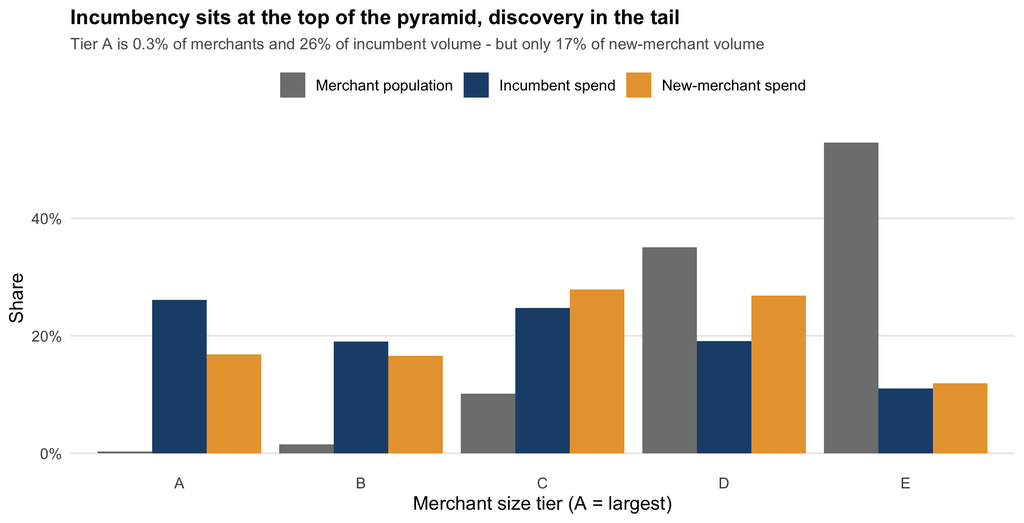

```r
ggplot(tier_flow, aes(most_recent_sales_range, share,
                      fill = factor(window, levels = c("Merchant population",
                                                       "Incumbent spend", "New-merchant spend")))) +
  geom_col(position = "dodge") +
  scale_y_continuous(labels = percent) +
  scale_fill_manual(values = PAL[c(6, 1, 4)], name = NULL) +
  labs(title = "Incumbency sits at the top of the pyramid, discovery in the tail",
       subtitle = "Tier A is 0.3% of merchants and 26% of incumbent volume - but only 17% of new-merchant volume",
       x = "Merchant size tier (A = largest)", y = "Share")
```

This is the most commercially loaded chart in the report.

- Tier A is **0.3% of merchants** but takes **26.1%** of incumbent transactions. These are the merchants a cardholder already uses.
- In the novelty window that same tier takes only **16.9%**, while tier D rises from 19.1% to **26.8%**.

**New commercial relationships form disproportionately in the long tail.** A promotion placed with a tier A merchant is, on this evidence, largely paying for traffic that was going to happen anyway. A promotion placed with a healthy tier C or D merchant is far more likely to be paying for a relationship that did not previously exist.

# 7 Region: where supply does not match demand

```r
geo <- full_join(hist_ok %>% count(state_id, name = "inc_txns"),
                 new_w   %>% count(state_id, name = "nov_txns"), by = "state_id") %>%
  full_join(merch %>% count(state_id, name = "merchants"), by = "state_id") %>%
  replace_na(list(inc_txns = 0, nov_txns = 0, merchants = 0)) %>%
  mutate(`Demand share`   = inc_txns / sum(inc_txns),
         `Novelty share`  = nov_txns / sum(nov_txns),
         `Supply share`   = merchants / sum(merchants),
         `Coverage index` = `Supply share` / `Demand share`,
         `Novelty index`  = `Novelty share` / `Demand share`) %>%
  arrange(desc(inc_txns))

geo %>% head(10) %>%
  mutate(across(c(`Demand share`, `Novelty share`, `Supply share`), ~percent(.x, 0.1)),
         across(c(`Coverage index`, `Novelty index`), ~round(.x, 2))) %>%
  select(state_id, inc_txns, `Demand share`, `Supply share`, `Coverage index`,
         `Novelty share`, `Novelty index`) %>%
  kable(col.names = c("State", "Transactions", "Demand share", "Supply share",
                      "Coverage", "Novelty share", "Novelty index"),
        format.args = list(big.mark = ","))
```

| State | Transactions | Demand share | Supply share | Coverage | Novelty share | Novelty index |
| --- | --- | --- | --- | --- | --- | --- |
| 9 | 36,105 | 38.9% | 27.7% | 0.71 | 39.2% | 1.01 |
| 16 | 7,272 | 7.8% | 9.9% | 1.27 | 6.5% | 0.84 |
| -1 | 6,203 | 6.7% | 3.5% | 0.53 | 4.7% | 0.70 |
| 15 | 5,493 | 5.9% | 8.1% | 1.38 | 8.0% | 1.35 |
| 5 | 5,351 | 5.8% | 7.0% | 1.22 | 7.0% | 1.21 |
| 20 | 4,536 | 4.9% | 4.7% | 0.96 | 4.2% | 0.85 |
| 11 | 3,913 | 4.2% | 2.2% | 0.52 | 2.4% | 0.57 |
| 21 | 3,682 | 4.0% | 4.1% | 1.03 | 2.6% | 0.64 |
| 19 | 3,387 | 3.6% | 5.6% | 1.54 | 4.2% | 1.15 |
| 22 | 2,894 | 3.1% | 2.0% | 0.63 | 4.1% | 1.31 |

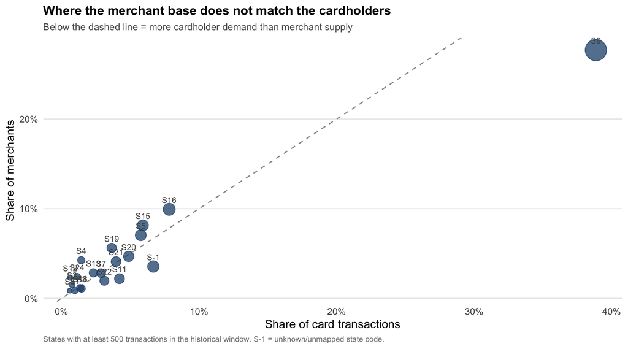

```r
geo %>% filter(inc_txns >= 500) %>%
  ggplot(aes(`Demand share`, `Supply share`)) +
  geom_abline(linetype = "dashed", colour = "grey60") +
  geom_point(aes(size = inc_txns), colour = PAL[1], alpha = .75) +
  geom_text(aes(label = paste0("S", state_id)), vjust = -1.1, size = 3, colour = "grey30") +
  scale_x_continuous(labels = percent) + scale_y_continuous(labels = percent) +
  scale_size_continuous(range = c(2, 10), guide = "none") +
  labs(title = "Where the merchant base does not match the cardholders",
       subtitle = "Below the dashed line = more cardholder demand than merchant supply",
       x = "Share of card transactions", y = "Share of merchants",
       caption = "States with at least 500 transactions in the historical window. S-1 = unknown/unmapped state code.")
```

State 9 alone is **39% of card demand** but only **28% of the merchant base** — a coverage index of 0.71, the largest under-served market in the network. States 15, 19 and 16 carry more merchants than their share of demand.

The more interesting column is the **novelty index**. State 22 has only 3.1% of demand but a novelty index of **1.31** — its cardholders try new merchants far more readily than the network average, on a merchant base that is proportionally thin. That combination is a merchant-acquisition target, not a discount target.

# 8 The novelty window: what discovery actually looks like

This is the file most teams ignore, and it is the only place in the export where a *new* commercial relationship is visible. A promotion that works creates exactly this event.

```r
data.frame(
  Metric = c("Transactions", "Cards", "Distinct merchants",
             "New merchants tried per card (2 months)",
             "Average ticket at a new merchant (BRL)",
             "Average ticket at a known merchant (BRL)",
             "Median ticket at a new merchant (BRL)",
             "Median ticket at a known merchant (BRL)"),
  Value = c(comma(nrow(new_w)), comma(n_distinct(new_w$card_id)),
            comma(n_distinct(new_m$merchant_id)),
            round(mean(tapply(new_m$merchant_id, new_m$card_id,
                              function(x) length(unique(x)))), 1),
            round(mean(new_w$amount_brl), 2), round(mean(hist_ok$amount_brl), 2),
            round(median(new_w$amount_brl), 2), round(median(hist_ok$amount_brl), 2))) %>%
  kable()
```

| Metric | Value |
| --- | --- |
| Transactions | 99,900 |
| Cards | 7,527 |
| Distinct merchants | 48,941 |
| New merchants tried per card (2 months) | 13.1 |
| Average ticket at a new merchant (BRL) | 118.7 |
| Average ticket at a known merchant (BRL) | 84.7 |
| Median ticket at a new merchant (BRL) | 48.05 |
| Median ticket at a known merchant (BRL) | 34.62 |

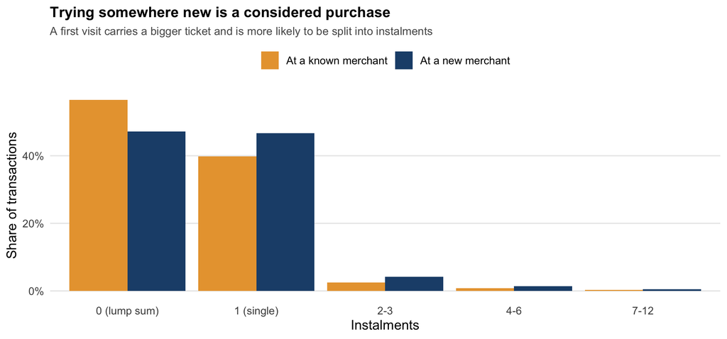

```r
novelty_instal <- bind_rows(
  hist_ok %>% filter(!is.na(instal_band)) %>% count(instal_band) %>%
    mutate(Window = "At a known merchant", share = n / sum(n)),
  new_w %>% filter(!is.na(instal_band)) %>% count(instal_band) %>%
    mutate(Window = "At a new merchant", share = n / sum(n)))

ggplot(novelty_instal, aes(instal_band, share, fill = Window)) +
  geom_col(position = "dodge") +
  scale_y_continuous(labels = percent) +
  scale_fill_manual(values = PAL[c(4, 1)], name = NULL) +
  labs(title = "Trying somewhere new is a considered purchase",
       subtitle = "A first visit carries a bigger ticket and is more likely to be split into instalments",
       x = "Instalments", y = "Share of transactions")
```

Three findings, each one actionable:

1. **A first visit costs 40% more.** R$118.70 at a new merchant against R$84.70 at a known one. Discovery is not impulse — it is a considered purchase, and it is worth more per transaction.
2. **Instalment use nearly doubles.** 2–3 instalment purchases run at 4.2% at new merchants against 2.5% at known ones. The one place where Elo’s cardholders do reach for instalments is a first purchase somewhere new. That is where an instalment-linked promotion would land, and nowhere else.
3. **Cardholders try roughly 13 new merchants in two months.** Appetite for discovery is not the constraint. Direction is.

# 9 The Q4 targeting map

We now put the demand side and supply side on one picture. Two indices per merchant subsector:

- **Novelty Capture Index (NCI)** = share of new-merchant volume ÷ share of incumbent volume. **Above 1** = cardholders come here to try something new. **Below 1** = they come here out of habit.
- **Coverage Index (COV)** = share of merchants ÷ share of incumbent volume. **Above 1** = more merchant supply than cardholder demand. **Below 1** = demand outruns supply.

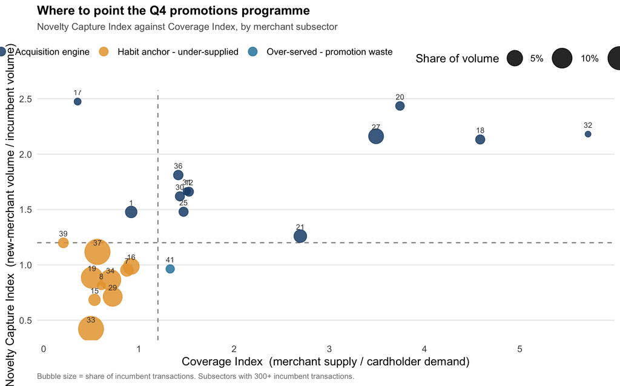

```r
sub_map <- full_join(hist_ok %>% count(subsector_id, name = "inc_txns"),
                     new_w   %>% count(subsector_id, name = "nov_txns"), by = "subsector_id") %>%
  full_join(merch %>% count(subsector_id, name = "merchants"), by = "subsector_id") %>%
  full_join(hist_ok %>% group_by(subsector_id) %>%
              summarise(avg_ticket = mean(amount_brl), .groups = "drop"), by = "subsector_id") %>%
  replace_na(list(inc_txns = 0, nov_txns = 0, merchants = 0)) %>%
  mutate(demand_share = inc_txns / sum(inc_txns),
         novelty_share = nov_txns / sum(nov_txns),
         supply_share = merchants / sum(merchants),
         NCI = novelty_share / demand_share,
         COV = supply_share / demand_share) %>%
  filter(inc_txns >= 300) %>%
  mutate(Role = case_when(
    NCI >= 1.2              ~ "Acquisition engine",
    COV >= 1.2              ~ "Over-served - promotion waste",
    TRUE                    ~ "Habit anchor - under-supplied")) %>%
  arrange(desc(demand_share))

ggplot(sub_map, aes(COV, NCI)) +
  geom_hline(yintercept = 1.2, linetype = "dashed", colour = "grey55") +
  geom_vline(xintercept = 1.2, linetype = "dashed", colour = "grey55") +
  geom_point(aes(size = demand_share, colour = Role), alpha = .85) +
  geom_text(aes(label = subsector_id), size = 2.8, vjust = -1.2, colour = "grey25") +
  scale_size_continuous(range = c(2.5, 12), labels = percent, name = "Share of volume") +
  scale_colour_manual(values = c("Acquisition engine" = PAL[1],
                                 "Habit anchor - under-supplied" = PAL[4],
                                 "Over-served - promotion waste" = PAL[2]), name = NULL) +
  guides(colour = guide_legend(nrow = 1, order = 1, override.aes = list(size = 4))) +
  labs(title = "Where to point the Q4 promotions programme",
       subtitle = "Novelty Capture Index against Coverage Index, by merchant subsector",
       x = "Coverage Index  (merchant supply / cardholder demand)",
       y = "Novelty Capture Index  (new-merchant volume / incumbent volume)",
       caption = "Bubble size = share of incumbent transactions. Subsectors with 300+ incumbent transactions.")
```

```r
sub_map %>%
  transmute(Subsector = subsector_id, Transactions = inc_txns,
            `Demand %` = percent(demand_share, 0.1),
            `Novelty %` = percent(novelty_share, 0.1),
            `Supply %` = percent(supply_share, 0.1),
            NCI = round(NCI, 2), COV = round(COV, 2),
            `Avg ticket` = round(avg_ticket, 0), Role) %>%
  kable(format.args = list(big.mark = ","))
```

| Subsector | Transactions | Demand % | Novelty % | Supply % | NCI | COV | Avg ticket | Role |
| --- | --- | --- | --- | --- | --- | --- | --- | --- |
| 37 | 17,486 | 18.8% | 21.0% | 10.6% | 1.12 | 0.56 | 49 | Habit anchor - under-supplied |
| 33 | 17,246 | 18.6% | 7.8% | 9.2% | 0.42 | 0.50 | 69 | Habit anchor - under-supplied |
| 19 | 11,161 | 12.0% | 10.6% | 6.1% | 0.88 | 0.51 | 71 | Habit anchor - under-supplied |
| 34 | 10,507 | 11.3% | 9.8% | 7.9% | 0.86 | 0.70 | 39 | Habit anchor - under-supplied |
| 29 | 8,269 | 8.9% | 6.3% | 6.4% | 0.71 | 0.72 | 87 | Habit anchor - under-supplied |
| 16 | 4,962 | 5.3% | 5.3% | 4.9% | 0.99 | 0.92 | 62 | Habit anchor - under-supplied |
| 27 | 4,111 | 4.4% | 9.6% | 15.4% | 2.16 | 3.49 | 175 | Acquisition engine |
| 21 | 2,494 | 2.7% | 3.4% | 7.2% | 1.26 | 2.70 | 148 | Acquisition engine |
| 7 | 2,445 | 2.6% | 2.5% | 2.3% | 0.95 | 0.87 | 85 | Habit anchor - under-supplied |
| 1 | 1,845 | 2.0% | 2.9% | 1.8% | 1.48 | 0.92 | 155 | Acquisition engine |
| 15 | 1,789 | 1.9% | 1.3% | 1.0% | 0.68 | 0.53 | 183 | Habit anchor - under-supplied |
| 39 | 1,111 | 1.2% | 1.4% | 0.2% | 1.20 | 0.21 | 20 | Habit anchor - under-supplied |
| 36 | 959 | 1.0% | 1.9% | 1.5% | 1.81 | 1.41 | 98 | Acquisition engine |
| 18 | 865 | 0.9% | 2.0% | 4.3% | 2.13 | 4.58 | 249 | Acquisition engine |
| 25 | 855 | 0.9% | 1.4% | 1.4% | 1.48 | 1.47 | 104 | Acquisition engine |
| 30 | 852 | 0.9% | 1.5% | 1.3% | 1.62 | 1.43 | 115 | Acquisition engine |
| 12 | 820 | 0.9% | 1.5% | 1.3% | 1.66 | 1.53 | 180 | Acquisition engine |
| 20 | 707 | 0.8% | 1.9% | 2.8% | 2.44 | 3.74 | 240 | Acquisition engine |
| 41 | 642 | 0.7% | 0.7% | 0.9% | 0.96 | 1.33 | 110 | Over-served - promotion waste |
| 8 | 626 | 0.7% | 0.5% | 0.4% | 0.81 | 0.61 | 42 | Habit anchor - under-supplied |
| 31 | 445 | 0.5% | 0.8% | 0.7% | 1.66 | 1.50 | 93 | Acquisition engine |
| 17 | 383 | 0.4% | 1.0% | 0.1% | 2.47 | 0.36 | 146 | Acquisition engine |
| 32 | 325 | 0.3% | 0.8% | 2.0% | 2.18 | 5.72 | 315 | Acquisition engine |

**Reading the map.**

*Top half — acquisition engines (subsectors 27, 18, 20, 32, 36, 12, 30, 25, 31, 21, 17, 1).* Subsector 27 is the clearest case: 4.4% of incumbent volume but **9.6% of novelty volume (NCI 2.16)**, sitting on 15.4% of the merchant base (COV 3.49). Cardholders are already willing to try new merchants here, and there is ample merchant supply to promote with. Average ticket R$175. This is where a discovery offer converts, and where the supply side can absorb the traffic.

*Bottom left — habit anchors, under-supplied (33, 29, 19, 34, 37, 16, 15, 7, 8, 39).* Subsector 33 is the network’s second largest at 18.6% of volume, but an **NCI of 0.42** — cardholders go where they always go. Discounting here buys transactions that were happening anyway. Its coverage index of 0.50 says demand outruns merchant supply, so the right intervention is **merchant recruitment, not cardholder discounting.**

*Bottom right — over-served (subsector 41).* More merchant supply than either demand or discovery justifies. A small quadrant on this data, but it is the one place where promotion spend is waste by construction.

*Subsector 37 deserves a line of its own.* At 18.8% of transactions it is the single largest, with an NCI of 1.12 — just below the discovery threshold — and a R$49 average ticket. It is the workhorse of the network: the place to defend top-of-wallet position, not the place to chase acquisition.

# 10 Recommendations for Q4

**1. Stop discounting habit. Redirect that budget to discovery.** Subsectors 33, 29, 19 and 34 together are **50.8% of transactions** and have novelty capture indices below 0.9. Money spent on offers here is subsidising purchases that would have happened. Moving even a third of that budget into the acquisition-engine quadrant (27, 18, 20, 32, 36) targets the same cardholders at the moment they are actually willing to change behaviour.

**2. Promote down the pyramid, not up it.** Tier A merchants are 0.3% of the base and 26% of incumbent volume, but only 17% of new-merchant volume. Set a floor: a defined share of Q4 promotional slots reserved for **accelerating tier C and D merchants**, which is where new relationships actually form, and where a merchant will value the traffic enough to fund part of the offer.

**3. Fix the `category_1 = Y` decline problem before spending.** That flag carries **4.3× the odds of a decline** and covers 6.1% of volume. Promoting into a population we then turn away costs money twice. This is a one-week question for the risk team and it should be answered before the Q4 calendar is locked.

**4. Use instalments in exactly one place: the first visit.** Instalment use nearly doubles at new merchants. An instalment-linked offer at a *known* merchant is fighting the network’s nature; at a first visit it works with it. This is the one instalment play the data supports.

**5. Recruit merchants where demand outruns supply.** State 9 (39% of demand, 28% of supply) and subsector 33 (18.6% of demand, coverage index 0.50) are merchant-acquisition problems wearing a promotions costume. State 22 — high novelty appetite, thin supply — is the cleanest greenfield in the network.

# 11 What this analysis cannot tell you

Stating the limits is part of the answer.

1. **No card-level loyalty file.** `train.csv` — with `first_active_month` and the loyalty `target` — was not in the export. We rebuilt tenure and value from observed behaviour, so we can describe what loyal behaviour *looks like* but cannot explain the score the business already computes.
2. **The two windows are different card samples.** 16 cards in common, so every novelty finding is a portfolio-level comparison, not a within-card before/after. It supports “where discovery happens”; it does not support “this promotion caused this card to switch”.
3. **463 cards is a small panel.** Portfolio-level conclusions on instalment mix, ticket size and concentration are stable; state-by-subsector cells with a few hundred transactions are indicative only.
4. **Everything is anonymised.** We can say subsector 27 behaves like a discovery category and subsector 33 like a habit category. Someone inside Elo has to put the names on them before this becomes a media plan.
5. **The currency transform is empirically recovered, not supplied.** It is validated by the shape of the resulting distribution — no negative amounts, an economically coherent median — but it should be confirmed against one known settlement record before any figure is quoted externally.
6. **Correlation, not causation.** The targeting map ranks where discovery already happens. Proving a promotion *causes* it needs a holdout test, which is the natural next piece of work.

# 12 Major learnings

- **Audit before you analyse.** 90% of the largest file was empty padding and a hundred records were about to hijack every average. Neither was flagged. The first hour of data work protected every number that followed.
- **Make the data speak the Board’s language.** Recovering the currency transform changed nothing statistically and changed everything about whether the analysis could be presented. “The median ticket is −0.69” is not a finding; “the median ticket is R$35” is a strategy.
- **The identity question was answered by a simple frequency table.** 96% single-payment settled what kind of network Elo is. No model was required — only asking the right question of the right column.
- **The file everyone ignores was the one that mattered.** The novelty window is the only view of a *new* relationship forming, which is precisely what a promotion is buying. Analysing it against the incumbent window turned a description into a recommendation.
- **Ratios travel further than totals.** Raw volume said “promote subsector 33, it is huge”. Volume *relative to* novelty and supply said the opposite. Two constructed indices changed the answer.
- **State the limits in the room.** Naming the 16-card overlap up front made the rest of the analysis credible rather than fragile.

```
## Analysis run: 28 Sep 2026 10:32 | R version 4.6.1 (2026-06-24)
```